# Red wine analysis

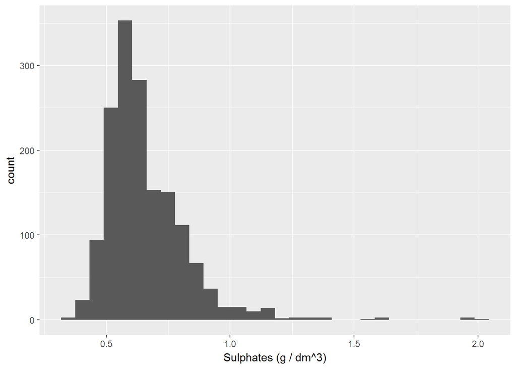

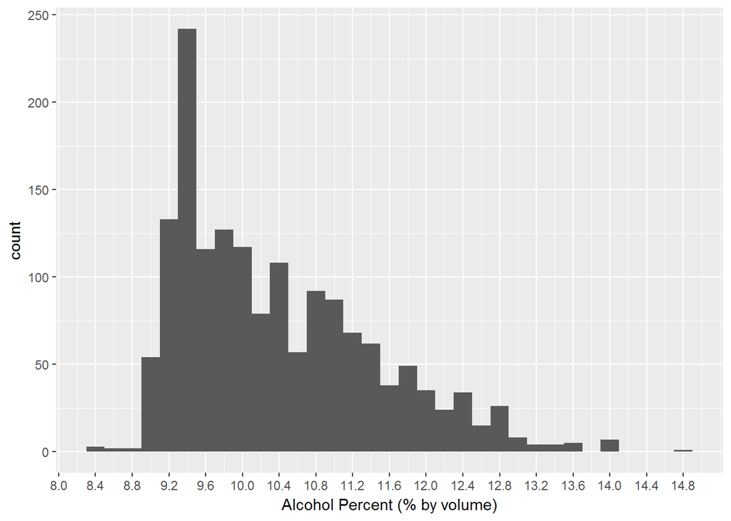

```
##    Min. 1st Qu.  Median    Mean 3rd Qu.    Max.
##    8.40    9.50   10.20   10.42   11.10   14.90
```

```
##
##  (8,10] (10,12] (12,15]
##     747     711     141
```

The max alcohol % is 14.9% and the minimum being 8.4%. There is a huge spike in the number of wines with an alcoholic percent around 9.4. The alcohol percents have been grouped into three ranges. They are 8-10% , 10-12% , 12-15%.

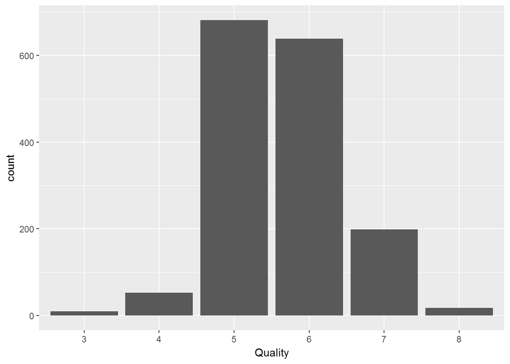

The quality of wines have been converted into a factor variable. As visible from the histogram, most wines are of the medium quality(5 & 6). A very few wines touch the lower and higher quality ranges.

It will be interesting to analyze what makes the red wine, good or bad

# Univariate Analysis

### What is the structure of your dataset?

The data set contains 13 variables with 1599 observations. One of the varable is the numbering used in the dataset. The various variables are :- 1. fixed.acidity  
2. volatile.acidity 3. citric.acid  
4. residual.sugar 5. chlorides  
6. free.sulfur.dioxide  
7. total.sulfur.dioxide  
8. density  
9. pH  
10. sulphates 11. alcohol  
12. quality

### What is/are the main feature(s) of interest in your dataset?

The main feature of interest in the dataset is the quality of the red wines. What goes into makeing the wine quality good is interesting to analyze.

### What other features in the dataset do you think will help support your into your feature(s) of interest?

Features like acid content, sulphur dioxide content,alcohol percent, sulphates, chlorides, residual sugar contribute towards the quality of wines. Analyzing them will be of interest.

### Did you create any new variables from existing variables in the dataset?

Yes, two new variables were created. They are :-

1. free.sulfur.dioxide.proportion
2. alcohol.range

The first variable is the proportion of free SO2 to the total SO2. The second variable was created to group alcohol percents in 3 ranges.

### Of the features you investigated, were there any unusual distributions?Did you perform any operations on the data to tidy, adjust, or change the form of the data? If so, why did you do this?

The alcohol percent graph had a large peak at a particular bin. Most of the graphs followed a normal distribution, while some were skewed positively. The dataset is a tidy dataset and therefore no cleaning was required. In some of the earlier plots generated, values above the 95th percentile were ignored, to elimiate the long tail in the plots.

# Bivariate Plots Section

Plotting the graphs between the variables of the dataframe against each other using ggpairs function, provides us with the pearson correlation coefficient ‘r’ between the variables.

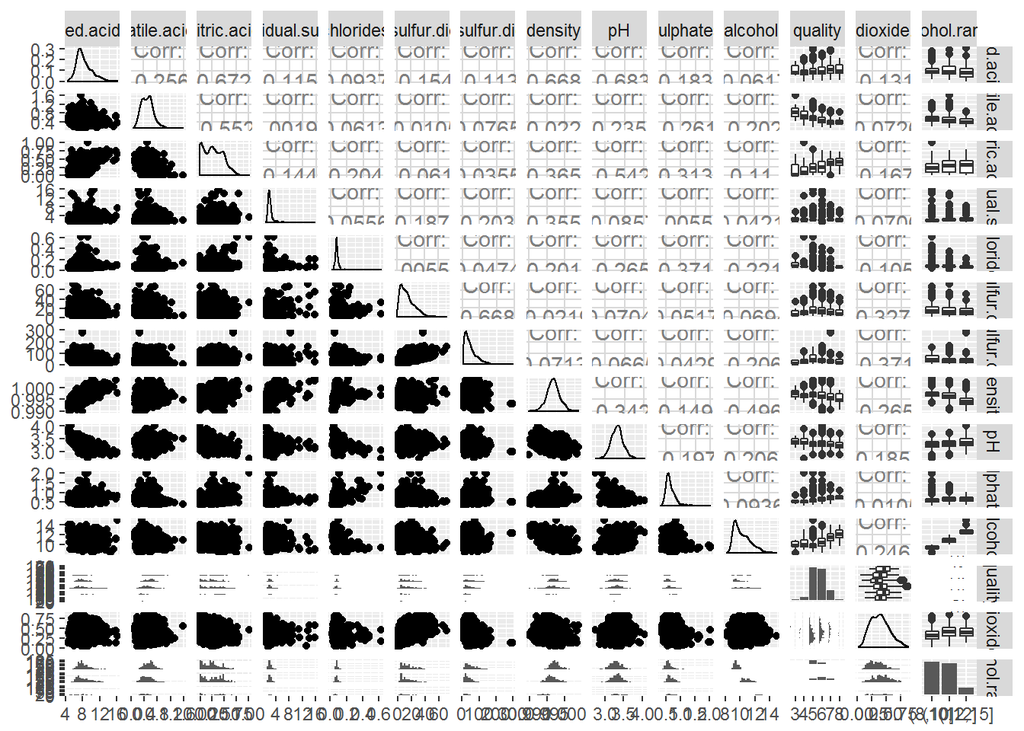

From the above correlation chart it seems like the quality of wine is correlated to varaibles like citric.acid,volatile.acidity,alcohol etc. Box plots have been created to understand these correlations. Quality has been converted to a categorical variable.

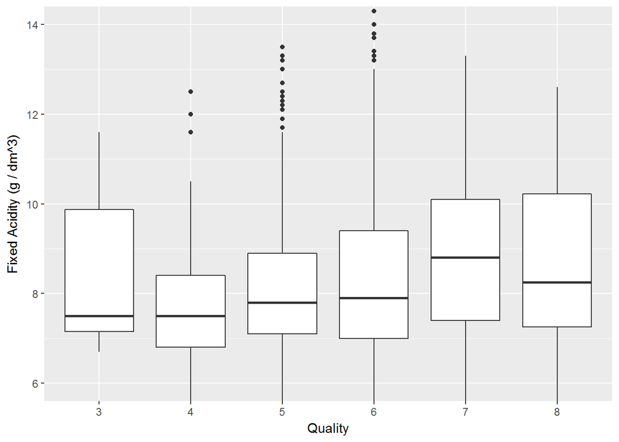

```
## red.wine$quality: 3
##    Min. 1st Qu.  Median    Mean 3rd Qu.    Max.
##   6.700   7.150   7.500   8.360   9.875  11.600
## --------------------------------------------------------
## red.wine$quality: 4
##    Min. 1st Qu.  Median    Mean 3rd Qu.    Max.
##   4.600   6.800   7.500   7.779   8.400  12.500
## --------------------------------------------------------
## red.wine$quality: 5
##    Min. 1st Qu.  Median    Mean 3rd Qu.    Max.
##   5.000   7.100   7.800   8.167   8.900  15.900
## --------------------------------------------------------
## red.wine$quality: 6
##    Min. 1st Qu.  Median    Mean 3rd Qu.    Max.
##   4.700   7.000   7.900   8.347   9.400  14.300
## --------------------------------------------------------
## red.wine$quality: 7
##    Min. 1st Qu.  Median    Mean 3rd Qu.    Max.
##   4.900   7.400   8.800   8.872  10.100  15.600
## --------------------------------------------------------
## red.wine$quality: 8
##    Min. 1st Qu.  Median    Mean 3rd Qu.    Max.
##   5.000   7.250   8.250   8.567  10.225  12.600
```

From the box plots for fixed acidity, we can see that the median value ranges above 8 g/dm^3 for high quality wines.The increase in fixed acidity is not too significant between the lower quality and higher quality. The mean for most of the qualities ranges above 8 g/dm^3. Note that the fixed acidity variable actually records the tartaric acid content in wine.

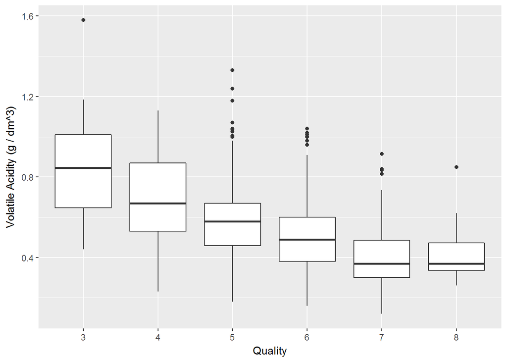

```
## red.wine$quality: 3
##    Min. 1st Qu.  Median    Mean 3rd Qu.    Max.
##  0.4400  0.6475  0.8450  0.8845  1.0100  1.5800
## --------------------------------------------------------
## red.wine$quality: 4
##    Min. 1st Qu.  Median    Mean 3rd Qu.    Max.
##   0.230   0.530   0.670   0.694   0.870   1.130
## --------------------------------------------------------
## red.wine$quality: 5
##    Min. 1st Qu.  Median    Mean 3rd Qu.    Max.
##   0.180   0.460   0.580   0.577   0.670   1.330
## --------------------------------------------------------
## red.wine$quality: 6
##    Min. 1st Qu.  Median    Mean 3rd Qu.    Max.
##  0.1600  0.3800  0.4900  0.4975  0.6000  1.0400
## --------------------------------------------------------
## red.wine$quality: 7
##    Min. 1st Qu.  Median    Mean 3rd Qu.    Max.
##  0.1200  0.3000  0.3700  0.4039  0.4850  0.9150
## --------------------------------------------------------
## red.wine$quality: 8
##    Min. 1st Qu.  Median    Mean 3rd Qu.    Max.
##  0.2600  0.3350  0.3700  0.4233  0.4725  0.8500
```

Volatile acidity seems to have a negative effect on quality. High quality alcohols have a low volatile acidity content.

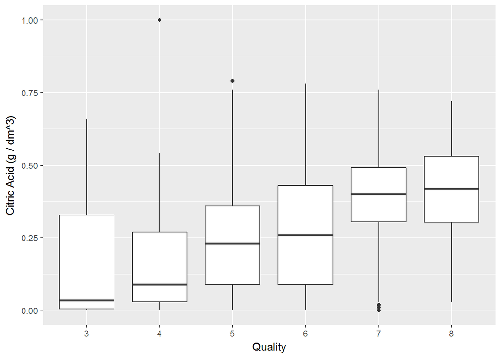

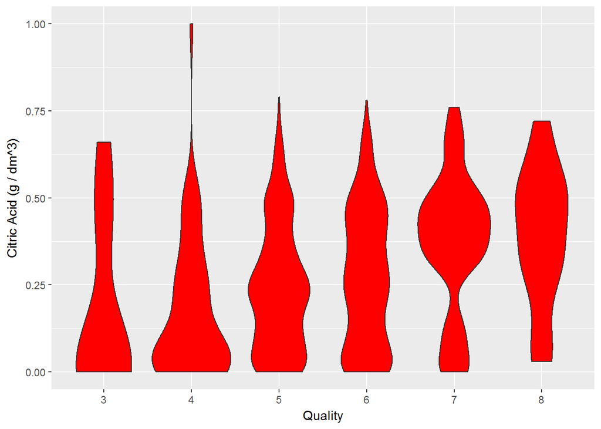

```
## red.wine$quality: 3
##    Min. 1st Qu.  Median    Mean 3rd Qu.    Max.
##  0.0000  0.0050  0.0350  0.1710  0.3275  0.6600
## --------------------------------------------------------
## red.wine$quality: 4
##    Min. 1st Qu.  Median    Mean 3rd Qu.    Max.
##  0.0000  0.0300  0.0900  0.1742  0.2700  1.0000
## --------------------------------------------------------
## red.wine$quality: 5
##    Min. 1st Qu.  Median    Mean 3rd Qu.    Max.
##  0.0000  0.0900  0.2300  0.2437  0.3600  0.7900
## --------------------------------------------------------
## red.wine$quality: 6
##    Min. 1st Qu.  Median    Mean 3rd Qu.    Max.
##  0.0000  0.0900  0.2600  0.2738  0.4300  0.7800
## --------------------------------------------------------
## red.wine$quality: 7
##    Min. 1st Qu.  Median    Mean 3rd Qu.    Max.
##  0.0000  0.3050  0.4000  0.3752  0.4900  0.7600
## --------------------------------------------------------
## red.wine$quality: 8
##    Min. 1st Qu.  Median    Mean 3rd Qu.    Max.
##  0.0300  0.3025  0.4200  0.3911  0.5300  0.7200
```

The presence of citric acid in the wine seems to improve the quality. There is a significant increase in the citric acid content as wine quality increases. Citric acid is one of the fixed acids found in wines. Although the fixed acid, tartaric acid doesnt play a significant role in quality, the fixed acid, citric acid improves the quality significantly. The violin plot shows the count at various levels of citric acid content based on quality.

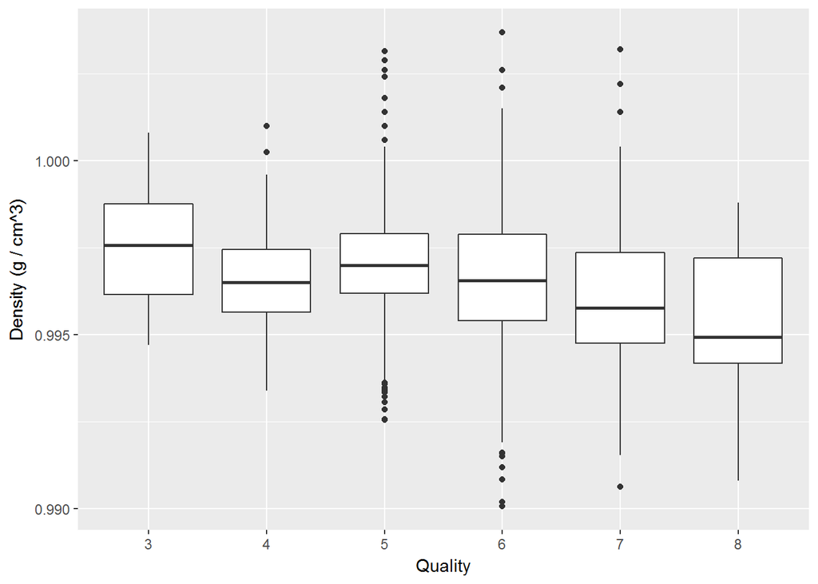

```
## red.wine$quality: 3
##    Min. 1st Qu.  Median    Mean 3rd Qu.    Max.
##  0.9947  0.9961  0.9976  0.9975  0.9988  1.0008
## --------------------------------------------------------
## red.wine$quality: 4
##    Min. 1st Qu.  Median    Mean 3rd Qu.    Max.
##  0.9934  0.9957  0.9965  0.9965  0.9974  1.0010
## --------------------------------------------------------
## red.wine$quality: 5
##    Min. 1st Qu.  Median    Mean 3rd Qu.    Max.
##  0.9926  0.9962  0.9970  0.9971  0.9979  1.0031
## --------------------------------------------------------
## red.wine$quality: 6
##    Min. 1st Qu.  Median    Mean 3rd Qu.    Max.
##  0.9901  0.9954  0.9966  0.9966  0.9979  1.0037
## --------------------------------------------------------
## red.wine$quality: 7
##    Min. 1st Qu.  Median    Mean 3rd Qu.    Max.
##  0.9906  0.9948  0.9958  0.9961  0.9974  1.0032
## --------------------------------------------------------
## red.wine$quality: 8
##    Min. 1st Qu.  Median    Mean 3rd Qu.    Max.
##  0.9908  0.9942  0.9949  0.9952  0.9972  0.9988
```

The mean and median density over quality doesn’t show a significant decrease.

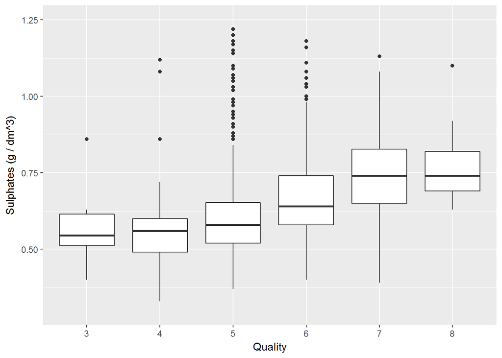

```
## red.wine$quality: 3
##    Min. 1st Qu.  Median    Mean 3rd Qu.    Max.
##  0.4000  0.5125  0.5450  0.5700  0.6150  0.8600
## --------------------------------------------------------
## red.wine$quality: 4
##    Min. 1st Qu.  Median    Mean 3rd Qu.    Max.
##  0.3300  0.4900  0.5600  0.5964  0.6000  2.0000
## --------------------------------------------------------
## red.wine$quality: 5
##    Min. 1st Qu.  Median    Mean 3rd Qu.    Max.
##   0.370   0.530   0.580   0.621   0.660   1.980
## --------------------------------------------------------
## red.wine$quality: 6
##    Min. 1st Qu.  Median    Mean 3rd Qu.    Max.
##  0.4000  0.5800  0.6400  0.6753  0.7500  1.9500
## --------------------------------------------------------
## red.wine$quality: 7
##    Min. 1st Qu.  Median    Mean 3rd Qu.    Max.
##  0.3900  0.6500  0.7400  0.7413  0.8300  1.3600
## --------------------------------------------------------
## red.wine$quality: 8
##    Min. 1st Qu.  Median    Mean 3rd Qu.    Max.
##  0.6300  0.6900  0.7400  0.7678  0.8200  1.1000
```

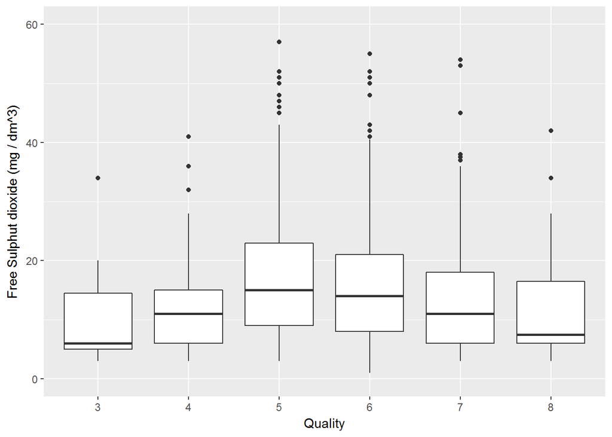

```
## red.wine$quality: 3
##    Min. 1st Qu.  Median    Mean 3rd Qu.    Max.
##     3.0     5.0     6.0    11.0    14.5    34.0
## --------------------------------------------------------
## red.wine$quality: 4
##    Min. 1st Qu.  Median    Mean 3rd Qu.    Max.
##    3.00    6.00   11.00   12.26   15.00   41.00
## --------------------------------------------------------
## red.wine$quality: 5
##    Min. 1st Qu.  Median    Mean 3rd Qu.    Max.
##    3.00    9.00   15.00   16.98   23.00   68.00
## --------------------------------------------------------
## red.wine$quality: 6
##    Min. 1st Qu.  Median    Mean 3rd Qu.    Max.
##    1.00    8.00   14.00   15.71   21.00   72.00
## --------------------------------------------------------
## red.wine$quality: 7
##    Min. 1st Qu.  Median    Mean 3rd Qu.    Max.
##    3.00    6.00   11.00   14.05   18.00   54.00
## --------------------------------------------------------
## red.wine$quality: 8
##    Min. 1st Qu.  Median    Mean 3rd Qu.    Max.
##    3.00    6.00    7.50   13.28   16.50   42.00
```

The sulphates level seems to increase with quality.The mean free sulphur dioxide presence in high quality wines shows a decline.

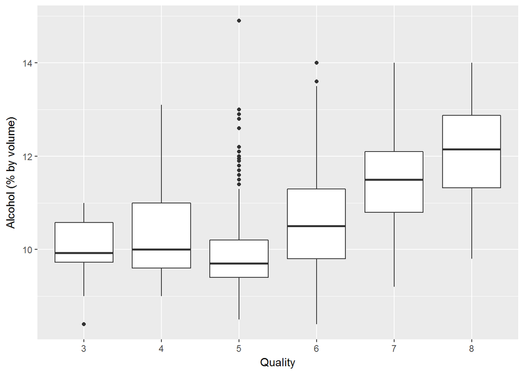

Finally we find the alcohol percent is higher in good quality wines.

From these box plots, we find that citric acid, volatile acids,sulphates, alcohol content in wines affect quality.

Lets look at some of the other relationships among variables.

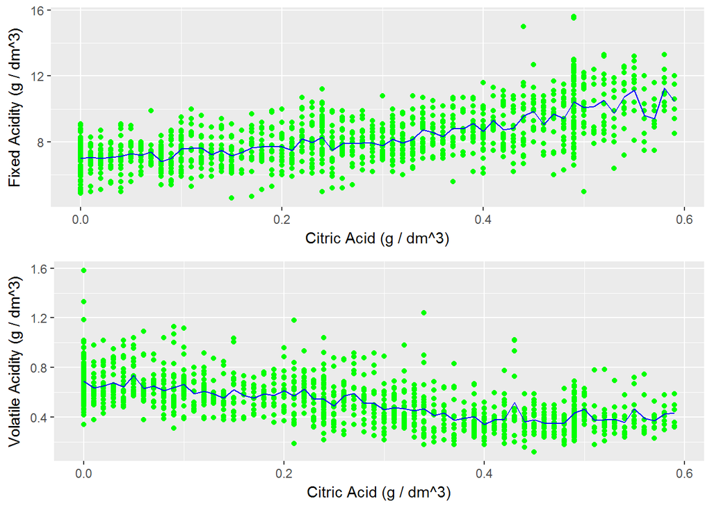

From the above plots we can see the positive correlation between citric acid and fixed acids and the negative correlation between citric acid and volatile acids. The mean fixed acidity and volatile acidity increases and decreases respectively as citric acid content increases.

There is a significant negative correlation between citric acid content and pH. This is because as acid contents increases the acidity of wines increases, this causes the pH value to drop. Remember the lower the pH value, the more acidic a wine is.

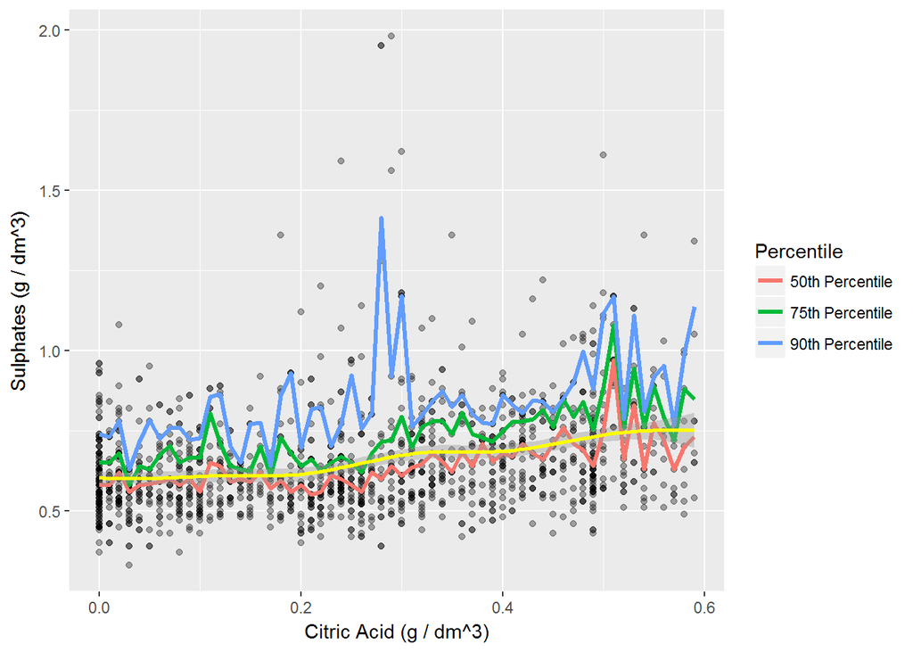

Although at lower levels of citric acid(under 0.2 g/dm^3) the sulphates level remains almost constant at citric acid levels above 0.2 g/dm^3 there is an increase in sulphates level. This can be infered from the yellow geom_smooth line.Both sulpahtes level and citric acid levels affect quality, so it will be interesting to see what happens when both are plotted against quality.

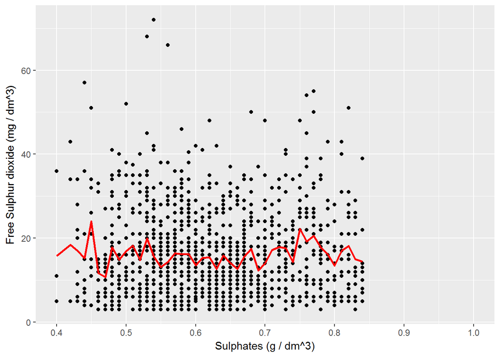

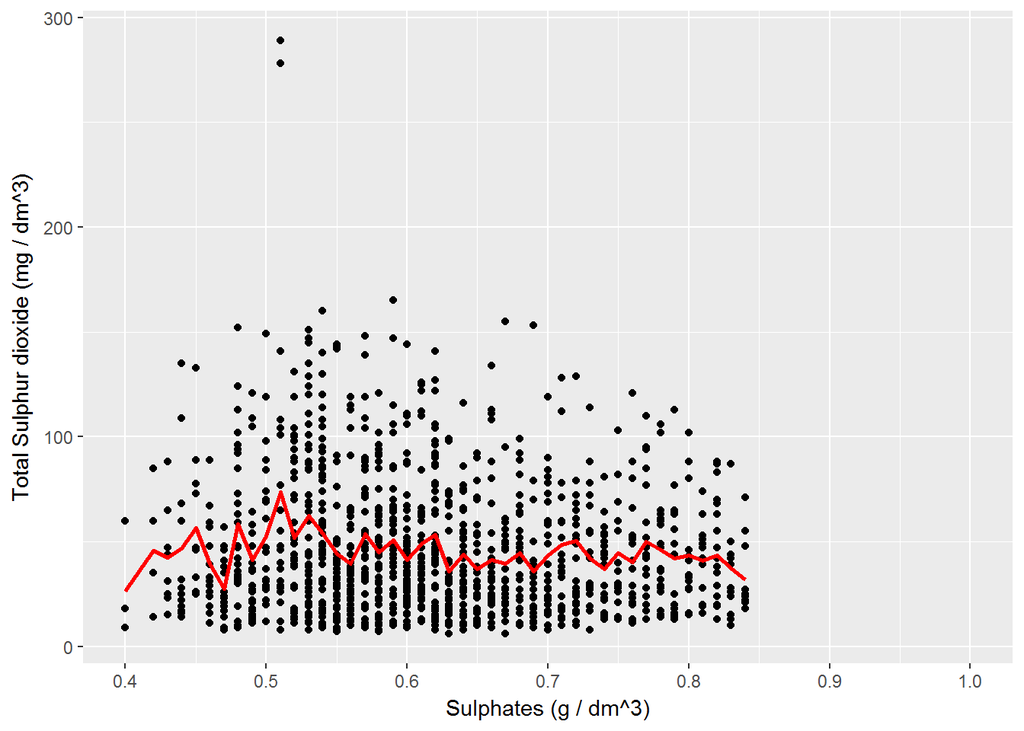

Free sulphur dioxide and total sulphur dioxide content aren’t affected by sulphates. This is strange because sulphates is a wine additive which can contribute to sulfur dioxide gas (S02) levels.

Citric acid content, sulphates level, alcohol percent and volatile acidity play a major role in wine quality.

# Bivariate Analysis

### Talk about some of the relationships you observed in this part of the investigation. How did the feature(s) of interest vary with other features in the dataset?

Citric acid content, sulphates level, alcohol percent and volatile acidity play a major role in wine quality. Citric acid content increases in high quality alcohols. Volatile acidity level is found to be less in high quality alcohols. Sulphates level are higher in good quality alcohols. Good quality alcohols also tend have a higher alcohol content.

### Did you observe any interesting relationships between the other features (not the main feature(s) of interest)?

The sulphates level doesn’t seem to affect the free sulphur diioxide or total sulphur dioxide levels, which reveals an interesting relationship.

### What was the strongest relationship you found?

The quality of wines is strongly related to the alcohol percent. Citric acid content is positively correlated while volatile acidity is negatively correlated to quality, but these relationships are not as strong as the one between quality and alcohol.

# Multivariate Plots Section

The new variable ‘alcohol.range’ created is a categorical variable splitting the alcohol percents into 3 ranges, 8-10,10-12,12-15.

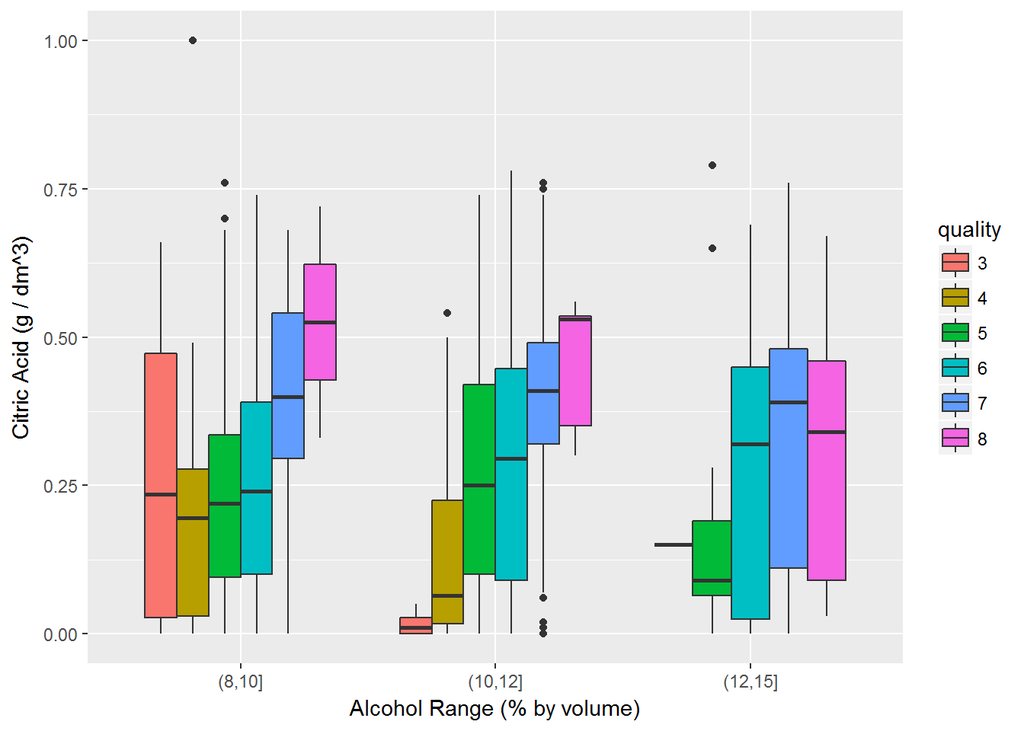

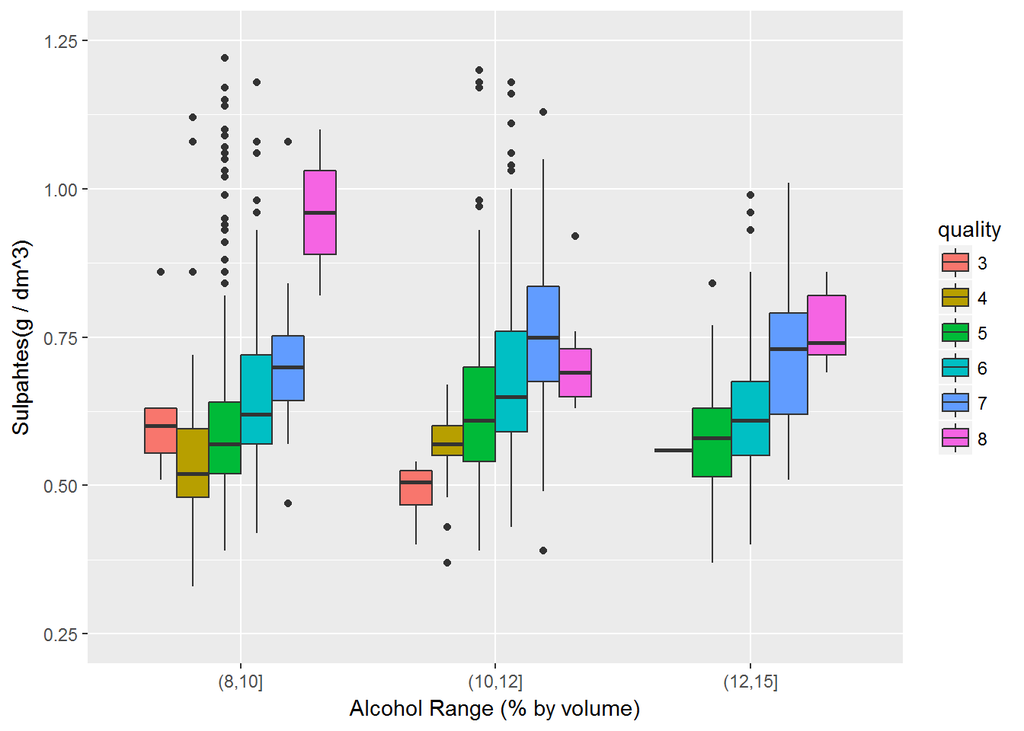

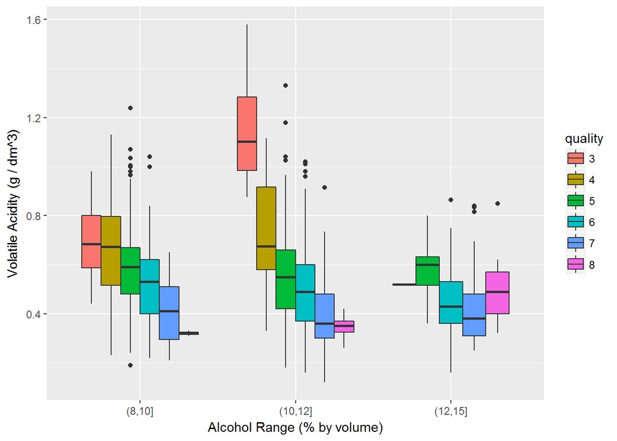

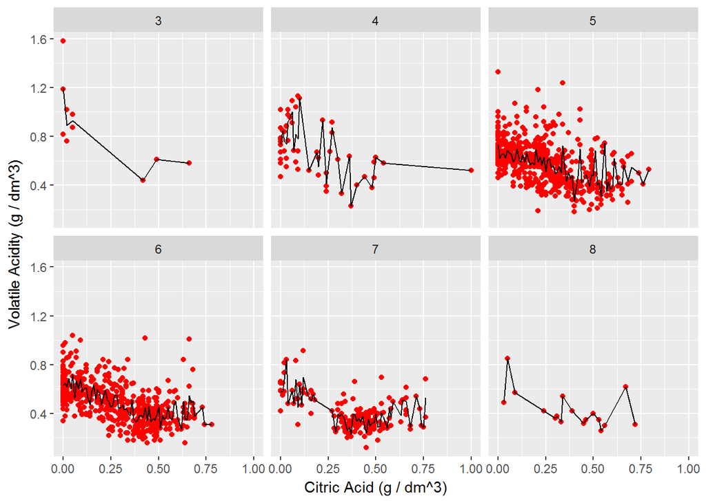

Looking at the citric acid vs volatile acidity plot faceted over wine quality, we find that as citric acid content increases volatile acidity decreases. This is evident in all quality alcohols, but in high quality alcohols between 7-8 the presence of volatile acids dips well below 0.4 g/dm^3.

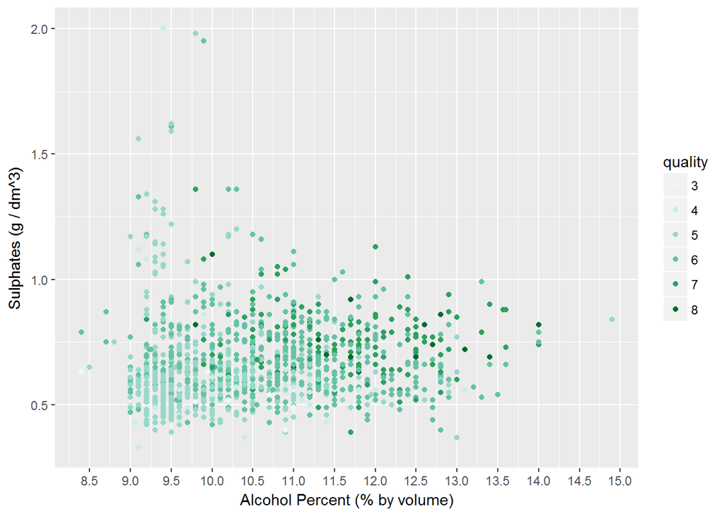

The above plot details the relationship between alcohol content and sulphates level over various quality levels. Higher quality wines lie in the higher alcohol ranges and tend to have higher sulphates level.

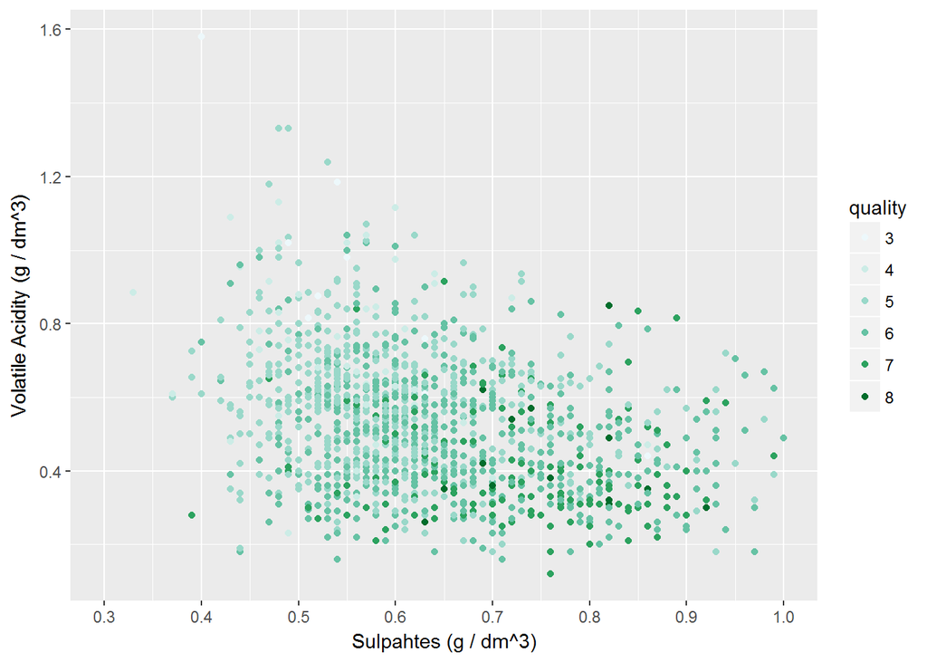

The above plot seems to show that good quality alcohols at higher sulphates level have lower volatile acidity.

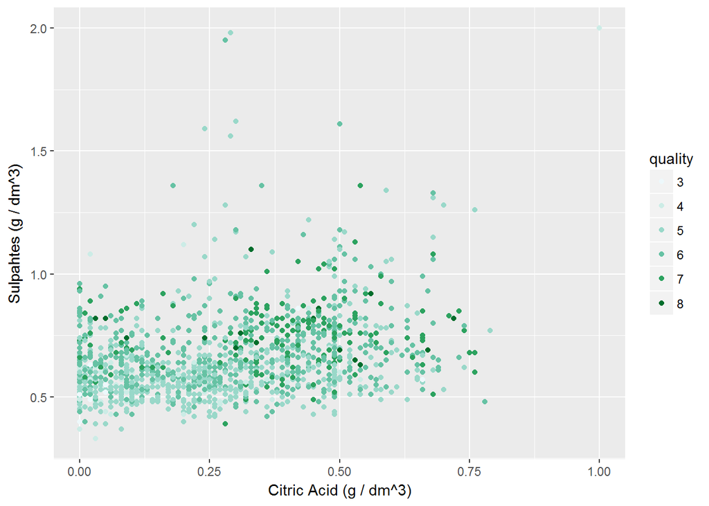

The above plot shows the sulphates vs citric acid levels. Good quality alcohols tend to have a higher sulphates level at various citric acid levels.

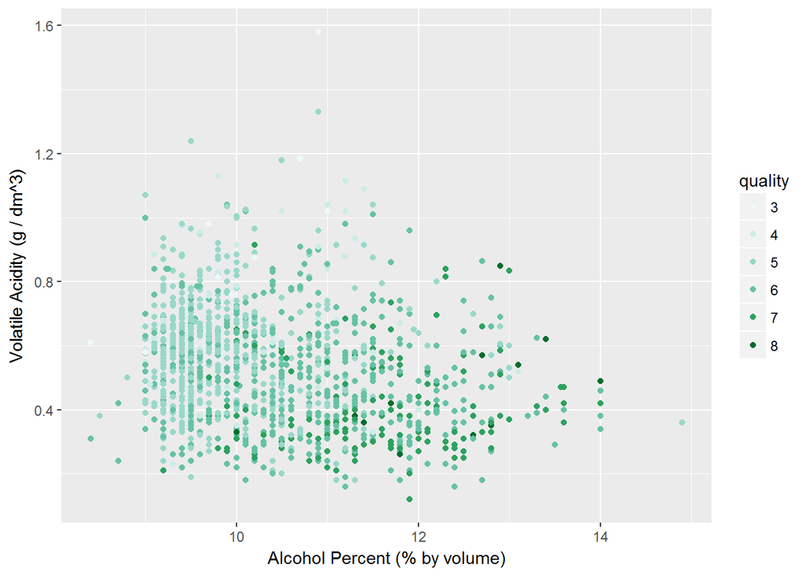

An increase in alcohol percent shows a decrease in volatile acidity in good quality alcohols.

Using citric acid content, volatile acidity, sulphates, quality a linear model has been created.

```
##
## Calls:
## m1: lm(formula = (I(red.wine$quality) ~ I(red.wine$alcohol)), data = red.wine)
## m2: lm(formula = I(red.wine$quality) ~ I(red.wine$alcohol) + red.wine$citric.acid,
##     data = red.wine)
## m3: lm(formula = I(red.wine$quality) ~ I(red.wine$alcohol) + red.wine$citric.acid +
##     red.wine$sulphates, data = red.wine)
## m4: lm(formula = I(red.wine$quality) ~ I(red.wine$alcohol) + red.wine$citric.acid +
##     red.wine$sulphates + red.wine$volatile.acidity, data = red.wine)
##
## =====================================================================================
##                                   m1            m2            m3            m4
## -------------------------------------------------------------------------------------
##   (Intercept)                    1.875***      1.830***      1.434***      2.646***
##                                 (0.175)       (0.171)       (0.176)       (0.201)
##   I(red.wine$alcohol)            0.361***      0.346***      0.338***      0.309***
##                                 (0.017)       (0.016)       (0.016)       (0.016)
##   red.wine$citric.acid                         0.730***      0.513***     -0.079
##                                               (0.090)       (0.093)       (0.104)
##   red.wine$sulphates                                         0.814***      0.696***
##                                                             (0.107)       (0.103)
##   red.wine$volatile.acidity                                               -1.265***
##                                                                           (0.113)
## -------------------------------------------------------------------------------------
##   R-squared                      0.227         0.257         0.284         0.336
##   adj. R-squared                 0.226         0.256         0.282         0.334
##   sigma                          0.710         0.696         0.684         0.659
##   F                            468.267       276.595       210.501       201.777
##   p                              0.000         0.000         0.000         0.000
##   Log-likelihood             -1721.057     -1688.711     -1659.955     -1599.093
##   Deviance                     805.870       773.917       746.576       691.852
##   AIC                         3448.114      3385.421      3329.910      3210.186
##   BIC                         3464.245      3406.930      3356.795      3242.448
##   N                           1599          1599          1599          1599
## =====================================================================================
```

The variables in this linear model can account for 33.6% of the variance in the quality of wines.

# Multivariate Analysis

### Were there any interesting or surprising interactions between features?

Volatile acidity showed a decline in all quality alcohols as citric acid content increased, with the difference being the percent of drop. The drop being higher in high quality alcohols. This was an interesting interaction.

### OPTIONAL: Did you create any models with your dataset? Discuss the strengths and limitations of your model.

Yes, i created a linear model between quality and alcohol percent.The variables in this linear model can account for 33.6% of the variance in the quality of wines.The R^2 value improved when volatile acidity was included. Only 33.6% of the variance could be explained by this model.

# Final Plots and Summary

### Plot One

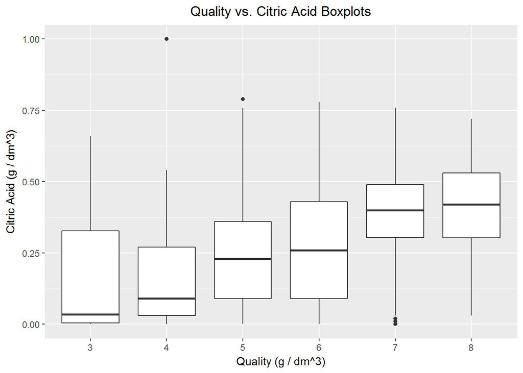

### Description One

The median citric acid values increases with quality. This can be infered from the above box plots. Similar box plots for other variables highlight the variance with quality.